# Prueba de t dos muestras

Jordan Golubov y José Arévalo

2026-04-16

# Pueba de t

La prueba de t es un método para comparar los promedios de dos poblaciones. Hay dos formas de comparar las muestras de dos poblaciones. la primera es cuando son poblaciones completamente *independientes*, por ejemplo, cuando se quiere comparara las alturas de los árboles de dos comunidades. Con estos tipos de datos, se realiza una prueba de t digamos que común y corriente. La segunda forma es cuando las dos poblaciones no son independientes, por ejemplo cuando tengo medidas del mismo árbol en dos ocasiones diferentes, esto quiere decir que la segunda medida no es independiente de la primera. En este caso se dice que es una prueba de *t pareada* en donde se comparara los proimedios de las poblaciones pero cada muestra tiene su *par* asociado.

La prueba de t funciona muy bien cuando los tamaños de la muestra de cada grupo a comparar son pequeños,, sin embargo no quiere decir que no tenga sus supuestos de cómo deben de estar los datos. La prueba de t de student sume que los datos en cada grupo tienen un distribución normal y las varianzas son iguales.

## Usemos unos datos.

Dentro del jardín botánico crece *Zephyranthes carinata* o mayitos. Es una especie de la familia Amaryllidaceae herbácea relativamente pequeña que tienen una floración muy cuantiosa en el mes de mayo. Se censaron dos parcelas decon mayitos, y a cada individuo se le midió la longitud total de la hoja más larga.

Primero tenemos que importar los datos

```r
mayitos <- read.csv("mayitos_1.csv", header=TRUE)
glimpse(mayitos)
```

```
## Rows: 273
## Columns: 2
## $ Parcela   <chr> "Parcela 1", "Parcela 1", "Parcela 1", "Parcela 1", "Parcela…
## $ long_hoja <dbl> 11, 17, 16, 14, 23, 16, 16, 9, 16, 11, 6, 11, 5, 5, 4, 6, 16…
```

Lo que nos dice es que la base de datos tiene 273 obervaciones en donde hay parcela en factor y longitudes de hoja. Los primero que debemos hacer es hacer una figura con los datos. Como hay dos parcelas podemos graficar la distribución de los datos por parcela. Si graficamos los dos tipos de parcelas podemos hacer una primera aproximación si se trata de dos promedios diferentes y además ver si los datos siguen una distribución normal con varianzas similares, de tal manera que podemos visualmente hacer una interpretación y además valorar los supuestos de la prueba de t.

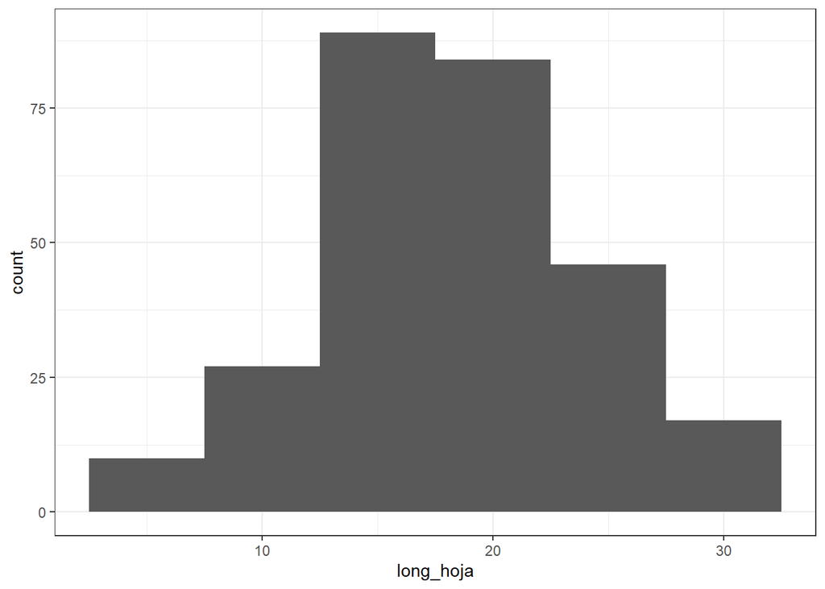

```r
mayitos.graph <- ggplot(mayitos, aes (x = long_hoja)) +
  geom_histogram(binwidth=5) +
  theme_bw()

mayitos.graph
```

```r
mayitos_por_parcela <- group_by(mayitos,Parcela) %>% summarise(long_hoja=mean(long_hoja))
mayitos_por_parcela
```

```
## # A tibble: 2 × 2
##   Parcela   long_hoja
##   <chr>         <dbl>
## 1 Parcela 1      15.6
## 2 Parcela 2      22.1
```

Tambien podemos hacer una gráfica de caja y bigote para darnos una idea de cómo se comporta la medida de tendencia central (la mediana) y la distribución de los datos.

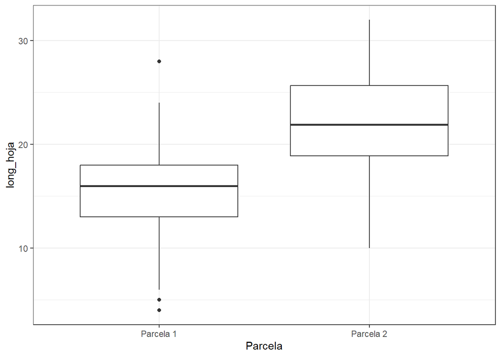

```r
mayitos.caja.y.bigote <- ggplot(mayitos, aes(x=Parcela, y = long_hoja)) +
  geom_boxplot(stat = 'boxplot', position = 'dodge2')+
  theme_bw()

mayitos.caja.y.bigote
```

Ahora que tenemos un poco de información de nuestros datos y de cómo se ven hacemos la prueba formal.

```r
prueba.t.mayito <- t.test(long_hoja ~ Parcela, data = mayitos)
prueba.t.mayito
```

```
##
##  Welch Two Sample t-test
##
## data:  long_hoja by Parcela
## t = -10.971, df = 246.59, p-value < 2.2e-16
## alternative hypothesis: true difference in means between group Parcela 1 and group Parcela 2 is not equal to 0
## 95 percent confidence interval:
##  -7.654685 -5.324465
## sample estimates:
## mean in group Parcela 1 mean in group Parcela 2
##                15.56209                22.05167
```

Los argumentos que le damos a la prueba de t son una entrada de tipo formula que contiene dos elementos separados por una tilde. Este formato es equivalente a si tuvieramos algo como $y = x$, en donde el primer elemento a la izquierda de la tilde es la variable de respuesta (la $y$) y lo que se encuentra a la derecha de la tilde es la variable explicatoria (la $x$). Despues de la coma, es el conjunto de datos que se van a utilizar en donde se encuentran los datos de parcela y longitud de la hoja.

La salida requiere un poco de explicación. El primer renglón nos dice el tipo de prueba que se realizó, en este caso una prueba de t de dos muestras de Welch. Si usamos una prueba de Welch relajamos un poco el supuesto de igualdad de las varianzas. Podemos probarlo con una prueba que tiene la misma estructura que la prueba de t.

```r
var.test(long_hoja ~ Parcela, data = mayitos)
```

```
##
##  F test to compare two variances
##
## data:  long_hoja by Parcela
## F = 0.86693, num df = 152, denom df = 119, p-value = 0.4052
## alternative hypothesis: true ratio of variances is not equal to 1
## 95 percent confidence interval:
##  0.6143958 1.2145489
## sample estimates:
## ratio of variances
##          0.8669334
```

La parte importante es el valor de de p. Esto nos dice que no hay diferencias de las varianzas dentro de cada grupo, es decir no violamos el supuesto de la prueba de t.

Lo siguiente es el resultado típico de una prueba de t, el estadístico t, los grados de libertad y el valor de p. Además, la prueba nos dice algo acerca de la hipótesis que estamos probando, en este caso que las diferencias que estamos probando **NO** son iguales a 0. En otras palabras, si las diferencias son iguales a 0 entonces son iguales.

Lo siguiente es intervalo de confianza al 95%, que es alrededor de la diferencia entre los dos promedios. Si la diferencia fuera de 0 (i.e. iguales), entonces los valores del intervalo incluirían el valor de 0. Finalmente, la salida provee el promedio de cada grupo y en conclusión podemos decir que hay diferencias en la longitud del tamaño de la hoja entre las dos parcelas analizadas.